# Modelagem e Função de Transferência

Sistemas de Controle I — Controle Clássico

Prof. Dr. Raphael Teixeira

Universidade Federal do Pará

## Transformada de Laplace — Revisão

A **Transformada de Laplace** converte equações diferenciais lineares em equações algébricas:

$$\mathcal{L}\{f(t)\} = F(s) = \int_0^{\infty} f(t)\,e^{-st}\,dt, \qquad s = \sigma + j\omega \in \mathbb{C}$$

**Propriedade fundamental — derivação (condições iniciais nulas):**

$$\mathcal{L}\left\{\frac{d^n f}{dt^n}\right\} = s^n F(s)$$

| Propriedade | Expressão |
| --- | --- |
| Linearidade | $\mathcal{L}\{\alpha f + \beta g\} = \alpha F(s) + \beta G(s)$ |
| Deslocamento em $s$ | $\mathcal{L}\{e^{-at}f(t)\} = F(s+a)$ |
| Valor final | $\displaystyle\lim_{t\to\infty} f(t) = \lim_{s\to 0} sF(s)$ (se o limite existir) |
| Valor inicial | $f(0^+) = \displaystyle\lim_{s\to\infty} sF(s)$ |

## Pares Notáveis da Transformada de Laplace

| $f(t)$, $t \geq 0$ | $F(s)$ |
| --- | --- |
| $\delta(t)$ — impulso unitário | $1$ |
| $u(t)$ — degrau unitário | $\dfrac{1}{s}$ |
| $t$ — rampa unitária | $\dfrac{1}{s^2}$ |
| $e^{-at}$ | $\dfrac{1}{s+a}$ |
| $\sin(\omega t)$ | $\dfrac{\omega}{s^2+\omega^2}$ |
| $\cos(\omega t)$ | $\dfrac{s}{s^2+\omega^2}$ |
| $t\,e^{-at}$ | $\dfrac{1}{(s+a)^2}$ |

**Tip**

Tabelas completas de pares e propriedades estão em qualquer livro-texto de sinais e sistemas ou de controle (Ogata 2010; Nise 2015).

## Função de Transferência

**Definição**

A **função de transferência** $G(s)$ de um sistema LIT é a razão entre a transformada de Laplace da saída e a da entrada, **com condições iniciais nulas**:

$$G(s) = \frac{Y(s)}{U(s)}$$

Para a EDO geral $a_n y^{(n)} + \cdots + a_0 y = b_m u^{(m)} + \cdots + b_0 u$:

$$G(s) = \frac{b_m s^m + \cdots + b_1 s + b_0}{a_n s^n + \cdots + a_1 s + a_0} = \frac{N(s)}{D(s)}$$

- Raízes de $N(s)$: **zeros** de $G(s)$ — raízes de $D(s)$: **polos** de $G(s)$
- $D(s) = 0$ é a **equação característica** — seus polos determinam a resposta natural (transitória) do sistema

## Exemplo: Sistema Massa-Mola-Amortecedor

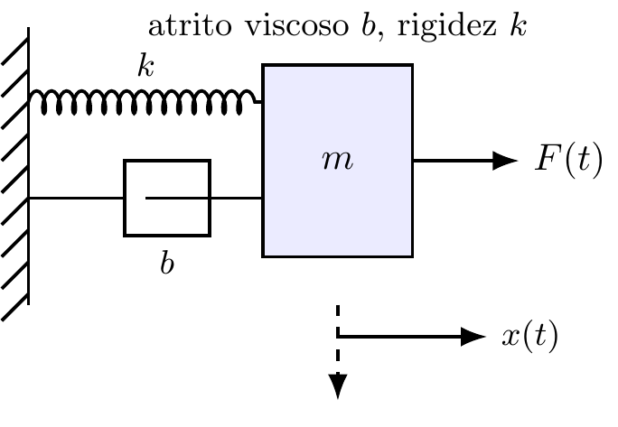

Pela 2ª lei de Newton ($F = m\,\ddot{x}$), com força aplicada $F(t)$, mola de rigidez $k$ e amortecedor viscoso $b$:

$$m\,\ddot{x}(t) + b\,\dot{x}(t) + k\,x(t) = F(t)$$

## Exemplo: Massa-Mola-Amortecedor — Função de Transferência

Aplicando Laplace com condições iniciais nulas à EDO $m\ddot{x} + b\dot{x} + kx = F$:

$$m\,s^2 X(s) + b\,s\,X(s) + k\,X(s) = F(s)$$

$$\boxed{G(s) = \frac{X(s)}{F(s)} = \frac{1}{m s^2 + b s + k}}$$

- Sistema de **segunda ordem**, sem zeros finitos, dois polos (reais ou complexos conjugados, conforme $b^2$ vs. $4mk$)
- Modelo idêntico (a menos de nomes de variáveis) ao de um circuito RLC série — a mesma matemática governa domínios físicos distintos

## Exemplo: Motor CC Controlado pela Armadura

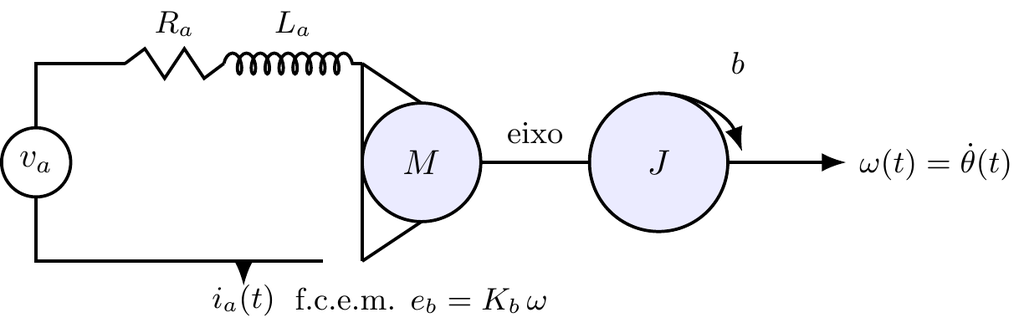

**Circuito de armadura:** $\quad v_a(t) = R_a\,i_a(t) + L_a\dfrac{di_a}{dt} + e_b(t), \qquad e_b(t) = K_b\,\omega(t)$

**Eixo (torque motor $= K_t\,i_a$):** $\quad J\dot\omega(t) + b\,\omega(t) = K_t\,i_a(t)$

## Motor CC — Função de Transferência

Aplicando Laplace (condições iniciais nulas) às duas equações e eliminando $I_a(s)$:

$$(R_a + L_a s)\,I_a(s) = V_a(s) - K_b\,\Omega(s), \qquad (Js+b)\,\Omega(s) = K_t\,I_a(s)$$

$$\boxed{\frac{\Omega(s)}{V_a(s)} = \frac{K_t}{(R_a+L_a s)(Js+b) + K_t K_b}}$$

- Se $L_a \approx 0$ (indutância de armadura desprezível), o modelo se reduz a **primeira ordem**:

$$\frac{\Omega(s)}{V_a(s)} \approx \frac{K_t}{R_a(Js+b) + K_t K_b} = \frac{K}{\tau s + 1}$$

**Tip**

Essa simplificação (motor CC de 1ª ordem) é usada com frequência nas próximas aulas para exemplos de controle de velocidade.

## Diagrama de Blocos

Um **diagrama de blocos** representa graficamente as relações entre subsistemas por meio de:

- **Blocos** — contêm a função de transferência do subsistema;
- **Setas** — indicam o sentido do fluxo de sinal (sempre unidirecional);
- **Somadores** (círculos) — somam/subtraem sinais, com o sinal indicado em cada seta de entrada;
- **Pontos de derivação** — o mesmo sinal segue para dois ou mais destinos.

**Tip**

Diagramas de blocos permitem **reduzir** sistemas interligados a uma única função de transferência equivalente — é o que faremos nos próximos slides.

## Álgebra de Blocos: Associação em Série

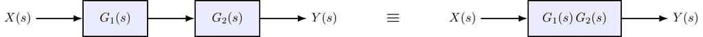

Blocos em cascata multiplicam suas funções de transferência:

$$G_{eq}(s) = G_1(s)\,G_2(s)$$

## Álgebra de Blocos: Associação em Paralelo

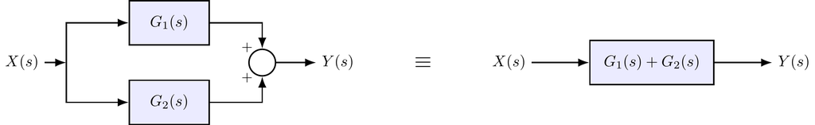

Blocos em paralelo (saídas somadas) têm suas funções de transferência somadas:

$$G_{eq}(s) = G_1(s) + G_2(s)$$

## Álgebra de Blocos: Realimentação

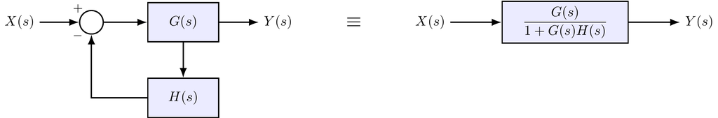

Para a malha com realimentação **negativa**:

$$Y(s) = G(s)\big[X(s) - H(s)Y(s)\big] \implies \boxed{G_{eq}(s) = \frac{Y(s)}{X(s)} = \frac{G(s)}{1+G(s)H(s)}}$$

Para realimentação **positiva**, o sinal do denominador se inverte: $G_{eq}(s) = \dfrac{G(s)}{1-G(s)H(s)}$.

**Important**

Esta é provavelmente a fórmula mais usada em todo o curso — memorize-a.

## Regra de Mason (Fórmula do Ganho)

Para diagramas de blocos com múltiplas malhas, a redução por álgebra de blocos pode ser trabalhosa. A **regra de Mason** calcula a função de transferência equivalente diretamente do grafo de fluxo de sinal:

$$G_{eq}(s) = \frac{\sum_k P_k \Delta_k}{\Delta}$$

- $P_k$: ganho do $k$-ésimo caminho direto (entrada → saída, sem repetir nó)
- $\Delta = 1 - \sum L_i + \sum L_i L_j - \sum L_i L_j L_k + \cdots$ (somas de ganhos de malhas individuais, produtos de malhas **não-tocantes** dois a dois, três a três, …)
- $\Delta_k$: cofator de $\Delta$ removendo as malhas que tocam o caminho $k$

**Tip**

Duas malhas são **não-tocantes** se não compartilham nenhum nó. A regra de Mason evita a álgebra passo a passo, mas exige cuidado na identificação de malhas e caminhos.

## Exemplo: Redução de um Diagrama com Múltiplas Malhas

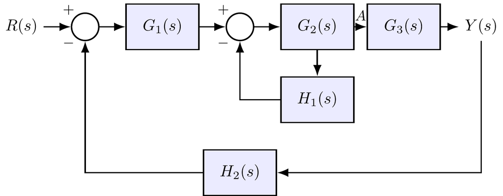

**Malhas:** $L_1 = -G_2H_1$ (em torno de $G_2$) e $L_2 = -G_1G_2G_3H_2$ (malha externa) — não-tocantes entre si apenas se não compartilharem nós (aqui compartilham, via $G_2$: são **tocantes**).

**Caminho direto:** $P_1 = G_1G_2G_3$, que toca ambas as malhas $\implies \Delta_1 = 1$.

## Exemplo — Solução por Mason

$$\Delta = 1 - (L_1+L_2) = 1 + G_2H_1 + G_1G_2G_3H_2$$

$$\boxed{\frac{Y(s)}{R(s)} = \frac{P_1\Delta_1}{\Delta} = \frac{G_1G_2G_3}{1+G_2H_1+G_1G_2G_3H_2}}$$

**Tip**

**Verificação por álgebra de blocos:** reduza primeiro a malha interna ($G_2$ com realimentação $H_1$) para $\dfrac{G_2}{1+G_2H_1}$, depois multiplique em série por $G_1$ e $G_3$, e finalmente feche a malha externa com $H_2$. O resultado é idêntico.

## Exercícios

1. Obtenha a função de transferência $X(s)/F(s)$ de um sistema massa-mola-amortecedor com $m=2\text{ kg}$, $b=4\text{ N·s/m}$, $k=8\text{ N/m}$.
2. Para o motor CC com $R_a=1\,\Omega$, $L_a\approx0$, $J=0{,}02\text{ kg·m}^2$, $b=0{,}1\text{ N·m·s}$, $K_t=K_b=0{,}05$, obtenha $\Omega(s)/V_a(s)$ na forma $K/(\tau s+1)$.
3. Reduza por álgebra de blocos um sistema com $G_1(s)$ e $G_2(s)$ em série, seguidos de realimentação unitária negativa em torno do conjunto.
4. Refaça o exemplo de redução com múltiplas malhas usando somente álgebra de blocos (sem Mason) e confirme o resultado obtido em aula.
5. Enuncie as condições para que duas malhas sejam consideradas “não-tocantes” na regra de Mason e dê um exemplo de diagrama onde isso ocorre.

## Referências

Nise, Norman S. 2015. *Engenharia de Sistemas de Controle*. 7th ed. LTC.

Ogata, Katsuhiko. 2010. *Engenharia de Controle Moderno*. 5th ed. Prentice Hall.